# Coming of Age Under Trump: Online Appendix

Author

Nikolaos Vichos

## Introduction

This document is the online appendix for the paper “Coming of Age Under Trump The Effect of First Electoral Exposure in a Trump Election on Long-Term Support for Liberal Democratic Protections of Media Freedom.” Here I have included additional methodological details not included in the main body of the paper.

## Regression Design

In my analysis, I estimated a series of sharp RD models using local polynomial regression. Each model used local linear estimation (polynomial order = 1) and MSE-optimal bandwidth selection to obtain the treatment effect at the cutoff.

## Index Construction

### Internal Consistency

To evaluate the internal consistency of the items used in the indices, I computed Cronbach’s α for each the aforementioned set of items. Both the raw and the standardized alpha (α = 0.7) show acceptable consistency (Taber 2018).

### Factor Structure

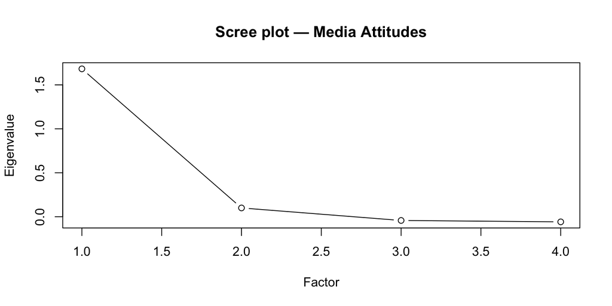

Figure 1: Scree Plot: Eigenvalues for Media Freedom Factors)

### Index Rescaling

Each index is constructed by extracting individual scores on the first factor and rescaling them to range from 0 to 1 using min–max normalization. Even though higher values indicate higher support for liberal democratic, this was reversed during production of the coefficient plot for visualization and interpretability purposes, due to the specific design of the rdrobust package (Calonico, Cattaneo, and Farrell 2025). In the package, the threshold is “crossed” from left to right—hence, normally, a positive effect would suggest more positive media attitudes among those who voted for the first time in *2012.* However, for clearer comprehension, the results have been reversed, and the indices can be interpreted in accordance with the wording of the hypotheses. For details on the process of index construction, refer to the replication code file.

## RD Results

The detailed estimates of the RDD are shown below in table format.

Regression Discontinuity Estimates on Support for Media Freedom

| Sample | Model | Estimate | SE | Bandwidth Type | Bandwidth (h) | N | Outcome |
| --- | --- | --- | --- | --- | --- | --- | --- |
| Full Sample | Without Controls | 0.022 | 0.030 | MSE-optimal | 9.38 | 1088 | Media Attitudes |
| Full Sample | With Controls | 0.015 | 0.030 | MSE-optimal | 9.18 | 1066 | Media Attitudes |
| Independents | Without Controls | 0.195 | 0.045 | MSE-optimal | 7.47 | 328 | Media Attitudes |
| Independents | With Controls | 0.163 | 0.044 | MSE-optimal | 8.02 | 351 | Media Attitudes |
| Partisans | Without Controls | -0.028 | 0.044 | MSE-optimal | 8.60 | 583 | Media Attitudes |
| Partisans | With Controls | -0.005 | 0.043 | MSE-optimal | 8.71 | 574 | Media Attitudes |
| Democrats | Without Controls | 0.022 | 0.049 | MSE-optimal | 9.24 | 379 | Media Attitudes |
| Democrats | With Controls | 0.050 | 0.044 | MSE-optimal | 9.35 | 375 | Media Attitudes |
| Republicans | Without Controls | -0.152 | 0.067 | MSE-optimal | 8.60 | 236 | Media Attitudes |
| Republicans | With Controls | -0.152 | 0.068 | MSE-optimal | 8.69 | 231 | Media Attitudes |

## Robustness Checks

I present the robustness checks conducted for the two models (Simple vs Controls) and for the three different RD estimates (Conventional, Bias-Adjusted, Bias-Adjusted with Robust SEs). I test the results’ robustness to different bandwidths, placebo cut-offs (different ages), and different polynomial degrees.

To narrow them down and improve readability, I only include subgroups that had statistically significant results (i.e., independents and Republicans). Overall, the sensitivity of the results to the first and third specifications, as well as to the addition of robust standard errors casts some doubt on their statistical significance.

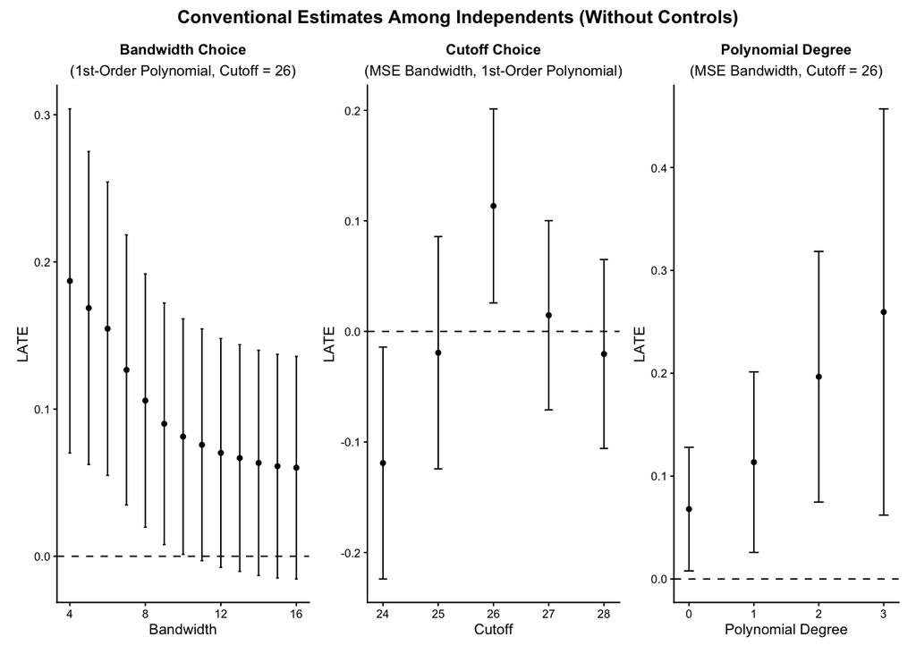

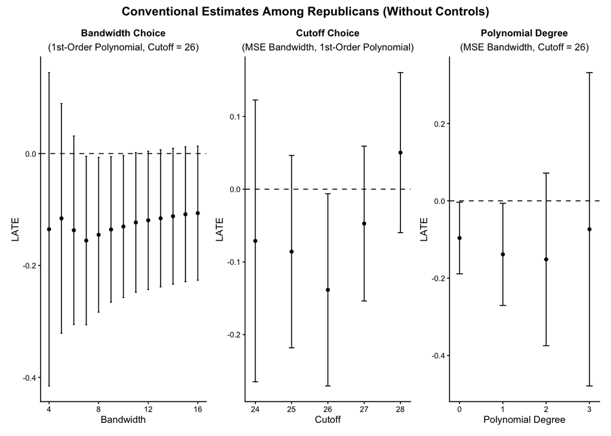

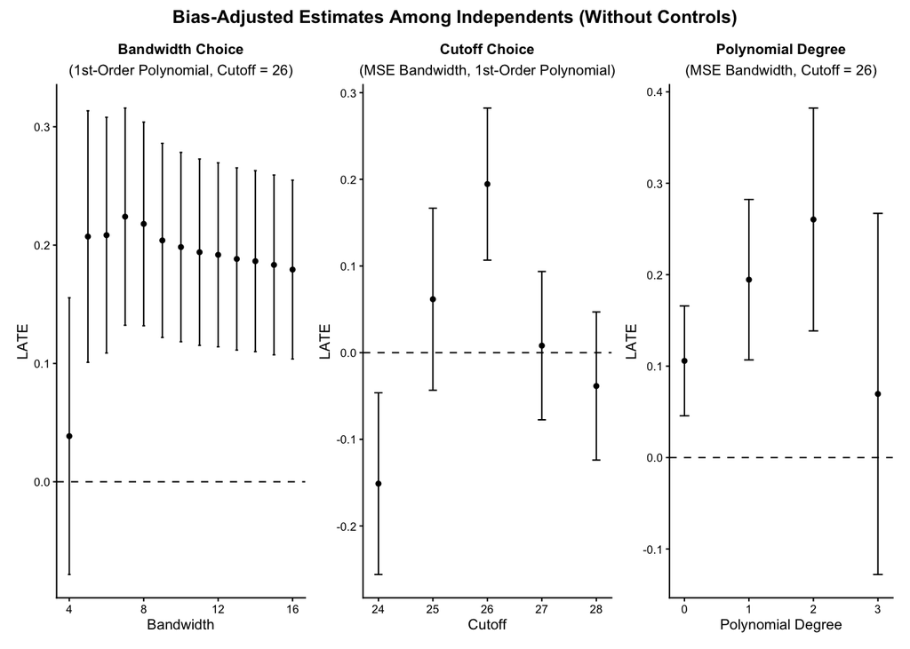

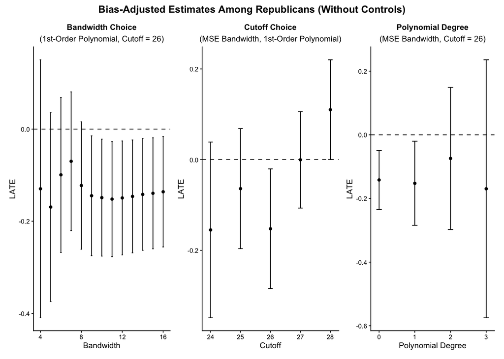

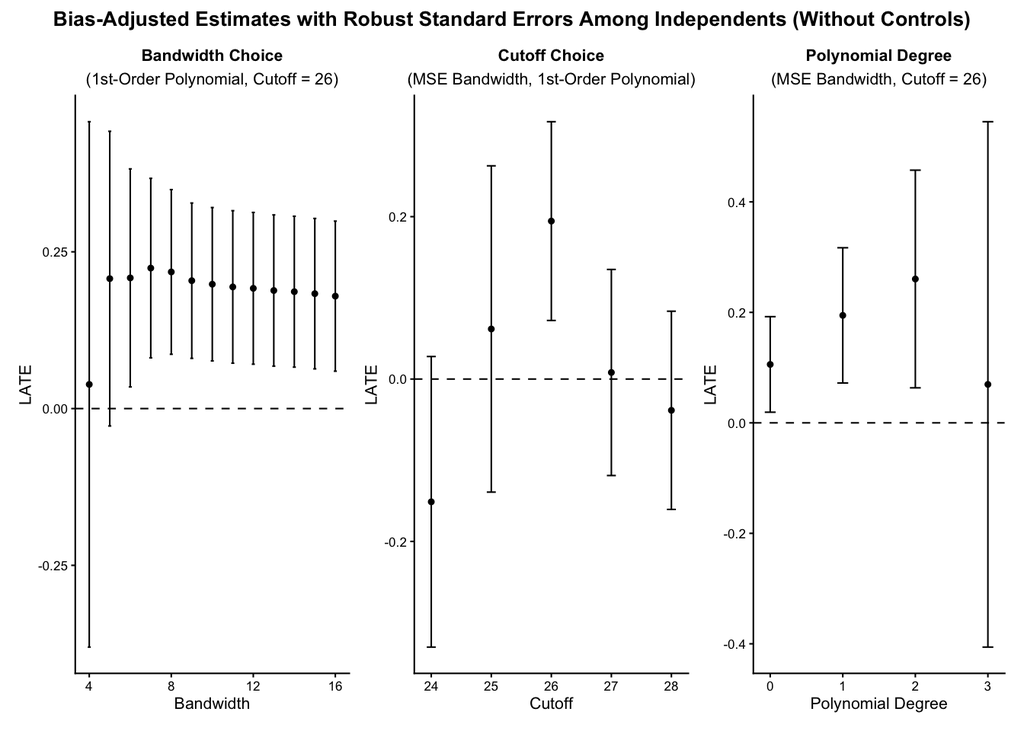

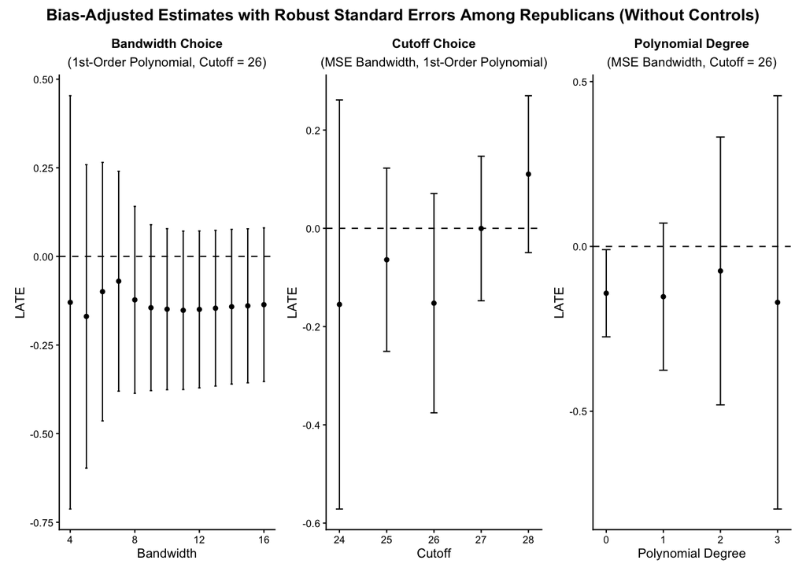

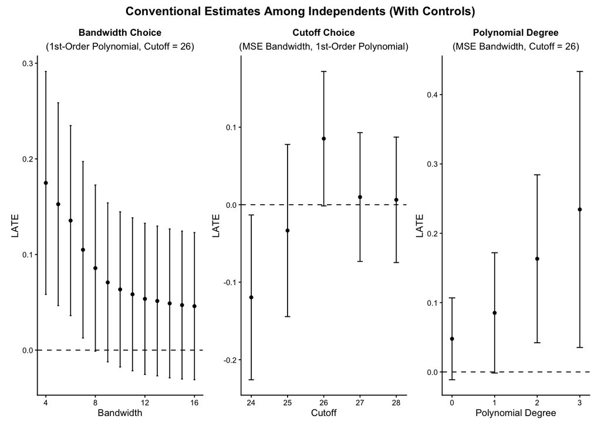

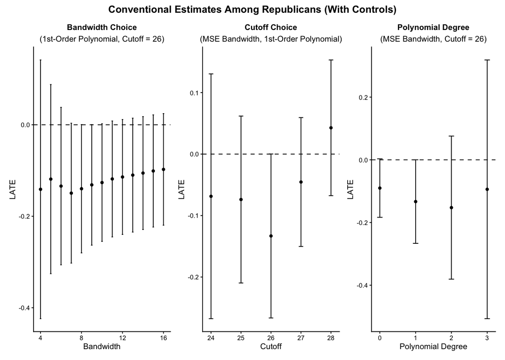

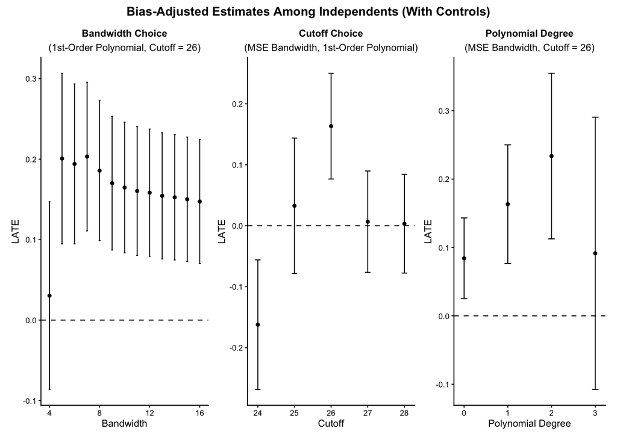

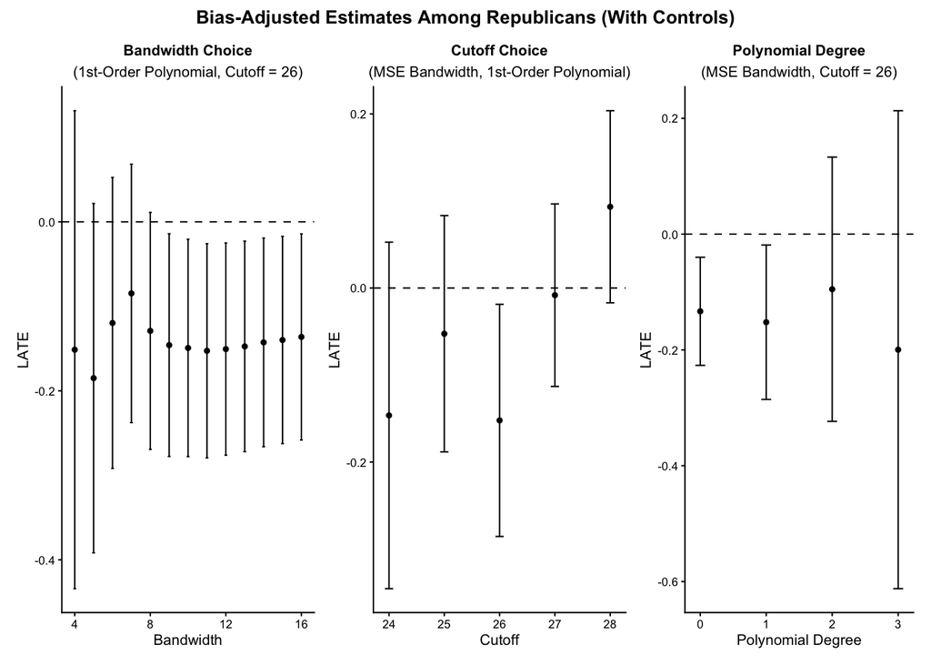

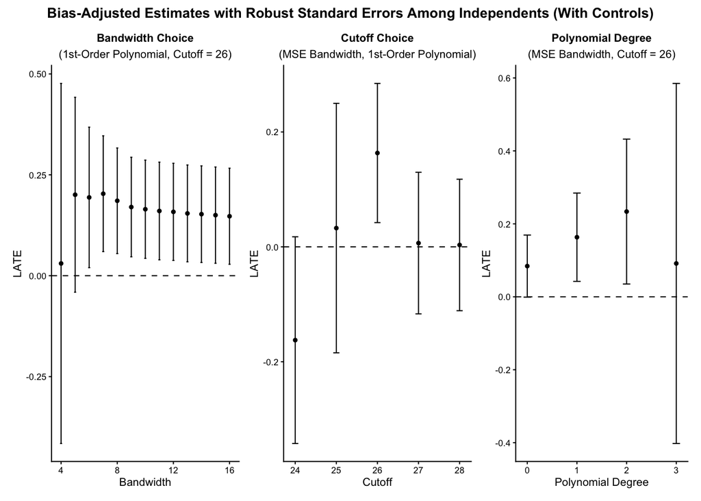

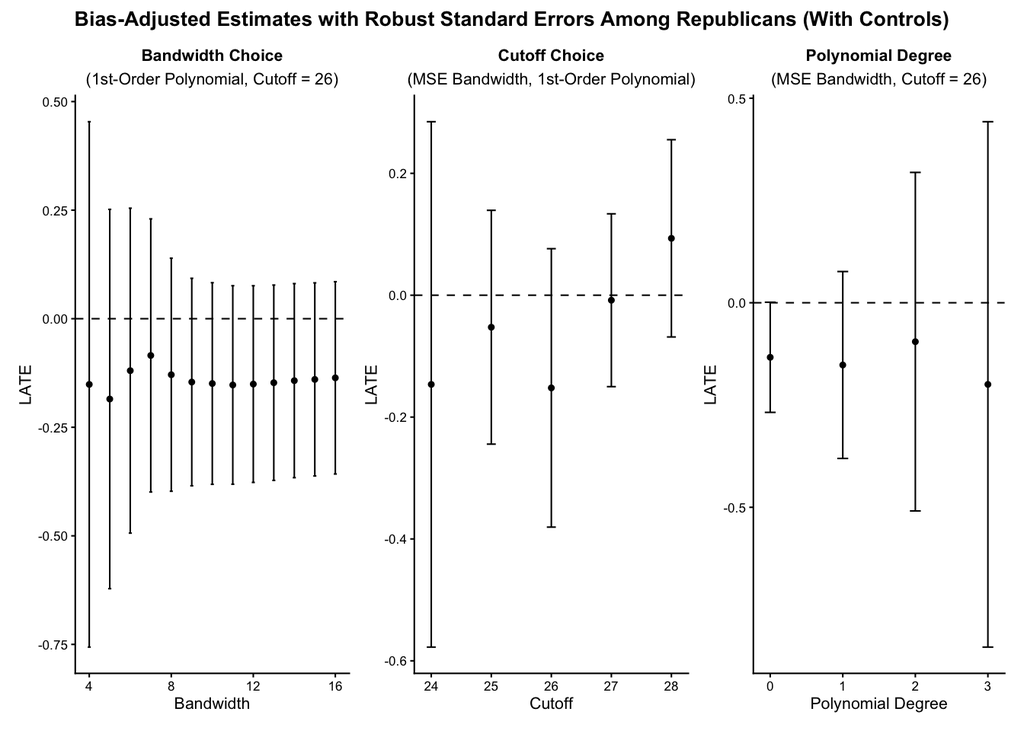

## References

Calonico, Sebastian, Matias D. Cattaneo, and Max H. Farrell. 2025. *Rdrobust: Robust Data-Driven Statistical Inference in Regression-Discontinuity Designs*. https://cran.r-project.org/web/packages/rdrobust/index.html.

Taber, Keith S. 2018. “The Use of Cronbach’s Alpha When Developing and Reporting Research Instruments in Science Education.” *Research in Science Education* 48 (6): 12731296. https://doi.org/10.1007/s11165-016-9602-2.